# project

2025-11-25

# Import Library

```r
# Libraries

# Data import and manipulation
library(readxl)
library(dplyr)
library(tidyverse)
```

[output not shown]

```r
# Visualization
library(ggplot2)
library(ellipse)
library(knitr)

# Multivariate analysis
#library(pls)
library(mixOmics)
```

[output not shown]

# Import dataset

```r
raw_df <- read_excel("41598_2018_29592_MOESM2_ESM.xlsx")
sex_labels <- unlist(raw_df[3, 17:136])
sex <- as.factor(sex_labels)

df <- read_excel("41598_2018_29592_MOESM2_ESM.xlsx", skip = 6)

#glimpse(df)
head(df)
```

```
## # A tibble: 6 × 136
##   ...1  ...2    ...3  ...4  ...5  ...6  ...7  ...8  ...9  ...10 `Male vs Female`
##   <chr> <chr>   <chr> <chr> <chr> <chr> <chr> <chr> <chr> <chr> <chr>
## 1 index Inchik… ret.… quan… BB id PubC… KEGG  know… PLS-… RSD … p_value
## 2 1     SRBFZH… 5432… 103   169   1351… C001… known 1.28… 0.21… 1.8724442897691…
## 3 2     QXKAIJ… 5907… 189   17400 10264 C023… known 0.44… 0.33… 0.9194788327754…
## 4 3     QXKAIJ… 5892… 333   3470  6602… C005… known 0.64… 0.14… 0.8743649511401…
## 5 4     HEBKCH… 5674… 217   5857  6912  C003… known 0.67… 0.14… 0.4791785193700…
## 6 5     LRFVTY… 7016… 353   1669  1188  C003… known 0.87… 0.36… 6.1963143703690…
## # ℹ 125 more variables: ...12 <chr>, `median Male/median Femal` <chr>,
## #   ...14 <chr>, treatment <chr>, `1 - Male...16` <chr>, `1 - Male...17` <chr>,
## #   `1 - Male...18` <chr>, `1 - Male...19` <chr>, `1 - Male...20` <chr>,
## #   `1 - Male...21` <chr>, `1 - Male...22` <chr>, `1 - Male...23` <chr>,
## #   `1 - Male...24` <chr>, `1 - Male...25` <chr>, `1 - Male...26` <chr>,
## #   `1 - Male...27` <chr>, `1 - Male...28` <chr>, `1 - Male...29` <chr>,
## #   `1 - Male...30` <chr>, `1 - Male...31` <chr>, `1 - Male...32` <chr>, …
```

```r
dim(df)
```

```
## [1] 415 136
```

# Cleaning and Data Transformation

```r
# organize names
# first df line has de colnames
colnames(df) <- as.character(unlist(df[1, ]))
df <- df[-1, , drop = FALSE]

# Convert measurement columns (17:end) to numeric explicitly
measure_cols <- 17:ncol(df)

for (i in measure_cols) {
  df[[i]] <- as.numeric(df[[i]])
}


X <- as.data.frame(df[, measure_cols])

colnames(X) <- paste0("S", seq_len(ncol(X)))
# number of metabolites and samples
if ("Metabolite" %in% colnames(df)) {
  rownames(X) <- df$Metabolite
}

dim(X)
```

```
## [1] 414 120
```

It matches with the article 120 samples (60 males + 60 females)

# Summary statistics

```r
summary(X)
```

```
##        S1                  S2                  S3                 S4
##  Min.   :     11.0   Min.   :     49.0   Min.   :    35.0   Min.   :    55.0
##  1st Qu.:    361.8   1st Qu.:    974.8   1st Qu.:   928.5   1st Qu.:   886.2
##  Median :    931.5   Median :   2567.0   Median :  2413.5   Median :  2200.0
##  Mean   :  10396.4   Mean   :  17884.3   Mean   : 15434.6   Mean   : 16240.0
##  3rd Qu.:   2820.5   3rd Qu.:   7546.2   3rd Qu.:  7103.8   3rd Qu.:  6561.8
##  Max.   :1159279.0   Max.   :1312984.0   Max.   :887773.0   Max.   :846476.0
##        S5                S6               S7                S8
##  Min.   :     57   Min.   :    49   Min.   :     63   Min.   :    36
##  1st Qu.:   1034   1st Qu.:  1218   1st Qu.:    871   1st Qu.:  1084
##  Median :   2678   Median :  3170   Median :   2626   Median :  2892
##  Mean   :  20265   Mean   : 17583   Mean   :  19948   Mean   : 15306
##  3rd Qu.:   7338   3rd Qu.:  9827   3rd Qu.:   8472   3rd Qu.:  7588
##  Max.   :1331535   Max.   :756697   Max.   :1085291   Max.   :654485
##        S9                S10                S11              S12
##  Min.   :    45.0   Min.   :    51.0   Min.   :    42   Min.   :    32
##  1st Qu.:   883.2   1st Qu.:   999.8   1st Qu.:   854   1st Qu.:   836
##  Median :  2420.0   Median :  2603.5   Median :  2386   Median :  2347
##  Mean   : 16003.7   Mean   : 16155.8   Mean   : 15655   Mean   : 14944
##  3rd Qu.:  8532.5   3rd Qu.:  7937.0   3rd Qu.:  7422   3rd Qu.:  7623
##  Max.   :613979.0   Max.   :979339.0   Max.   :662597   Max.   :600872
##       S13                 S14                 S15              S16
##  Min.   :     53.0   Min.   :     23.0   Min.   :    31   Min.   :    32
##  1st Qu.:    898.2   1st Qu.:    425.2   1st Qu.:   652   1st Qu.:   814
##  Median :   2714.5   Median :   1077.5   Median :  1932   Median :  2408
##  Mean   :  20509.0   Mean   :  12255.6   Mean   : 14991   Mean   : 15781
##  3rd Qu.:   8495.5   3rd Qu.:   2973.8   3rd Qu.:  5742   3rd Qu.:  7016
##  Max.   :1223172.0   Max.   :1357588.0   Max.   :664051   Max.   :923306
##       S17               S18                S19                 S20
##  Min.   :     45   Min.   :    43.0   Min.   :     37.0   Min.   :    57
##  1st Qu.:    802   1st Qu.:   872.5   1st Qu.:    760.8   1st Qu.:  1001
##  Median :   2398   Median :  2497.0   Median :   2002.5   Median :  2714
##  Mean   :  22298   Mean   : 14868.9   Mean   :  16331.1   Mean   : 16196
##  3rd Qu.:   8043   3rd Qu.:  7397.0   3rd Qu.:   5930.2   3rd Qu.:  6979
##  Max.   :1412185   Max.   :615658.0   Max.   :1047043.0   Max.   :718072
##       S21                 S22              S23                S24
##  Min.   :     63.0   Min.   :    42   Min.   :    19.0   Min.   :     35.0
##  1st Qu.:    829.8   1st Qu.:  1020   1st Qu.:   517.5   1st Qu.:    997.5
##  Median :   2398.0   Median :  2610   Median :  1475.0   Median :   2618.5
##  Mean   :  17775.5   Mean   : 16756   Mean   : 12719.6   Mean   :  17888.5
```

[output cut: 171 more lines]

```
##  Max.   :533155   Max.   :1037573.0   Max.   :1427015   Max.   :777934
##       S113             S114             S115             S116
##  Min.   :    48   Min.   :    33   Min.   :    82   Min.   :    41
##  1st Qu.:  1098   1st Qu.:  1011   1st Qu.:  1132   1st Qu.:  1107
##  Median :  3168   Median :  2760   Median :  2595   Median :  2692
##  Mean   : 17953   Mean   : 14737   Mean   : 16030   Mean   : 18147
##  3rd Qu.:  8649   3rd Qu.:  7086   3rd Qu.:  8018   3rd Qu.:  7900
##  Max.   :818457   Max.   :655562   Max.   :710631   Max.   :994444
##       S117               S118                S119               S120
##  Min.   :    42.0   Min.   :     45.0   Min.   :    51.0   Min.   :     21.0
##  1st Qu.:   859.8   1st Qu.:    989.5   1st Qu.:   926.2   1st Qu.:    421.5
##  Median :  2474.0   Median :   2849.0   Median :  2439.0   Median :   1033.0
##  Mean   : 14971.4   Mean   :  19385.2   Mean   : 17778.0   Mean   :  10041.5
##  3rd Qu.:  8341.2   3rd Qu.:   7703.2   3rd Qu.:  9066.8   3rd Qu.:   3205.0
##  Max.   :655882.0   Max.   :1265896.0   Max.   :944806.0   Max.   :1565960.0
```

```r
# Count total zero values
sum(X == 0, na.rm = TRUE)
```

```
## [1] 2
```

```r
# Missing values check
sum(is.na(X))
```

```
## [1] 0
```

# Is it the data Gaussian Distributed?

```r
par(mfrow=c(1,2))
hist(as.numeric(X[1,]), main="Raw Distribution", xlab="Intensity")
qqnorm(as.numeric(X[1,]), main="QQ Plot Raw")
qqline(as.numeric(X[1,]))
```

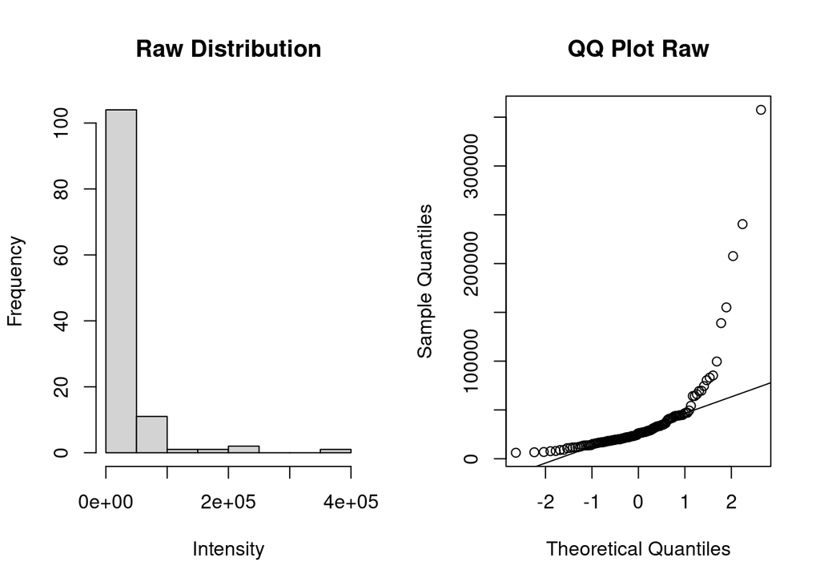

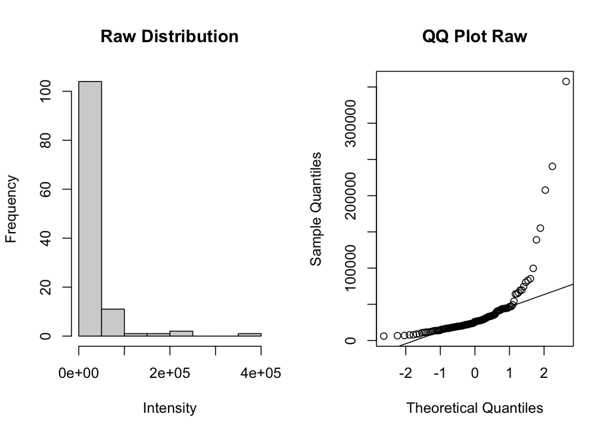

```r
par(mfrow=c(1,1))
```

# Histogram inspection

To assess distributional properties, histogram inspection was performed. Raw metabolite intensities showed pronounced right-skewness, supporting the need for a log-transformation to improve normality and stabilize variance prior to multivariate analysis.

```r
feat1 <- as.numeric(X[[1]]) #S1
feat2 <- as.numeric(X[[2]]) #S2

par(mfrow = c(2,2))

# Raw intensity distributions
hist(feat1, main = "Raw Intensities - Feature 1", xlab = "", col = "lightgray")
hist(feat2, main = "Raw Intensities - Feature 2", xlab = "", col = "lightgray")

# After log10 transformation
hist(log10(feat1 + 1), main = "Log10 - Feature 1", xlab = "", col = "lightgray")
hist(log10(feat2 + 1), main = "Log10 - Feature 2", xlab = "", col = "lightgray")
```

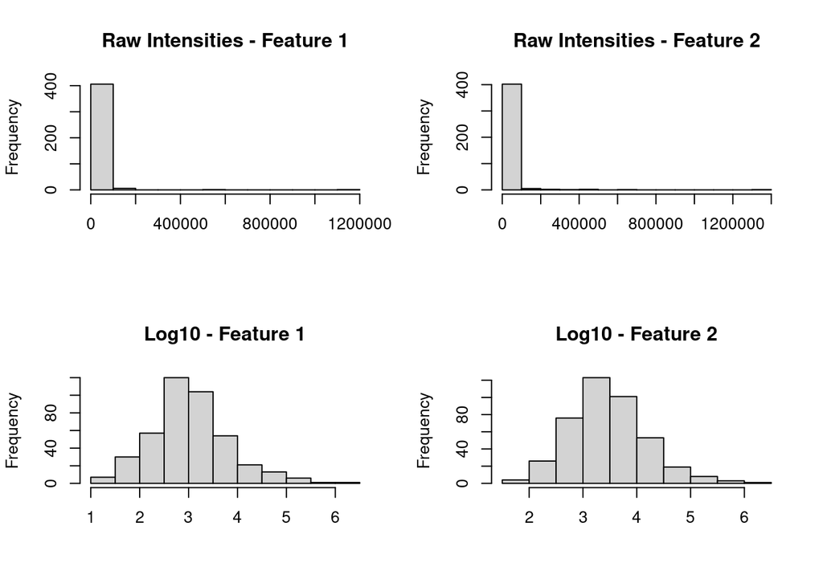

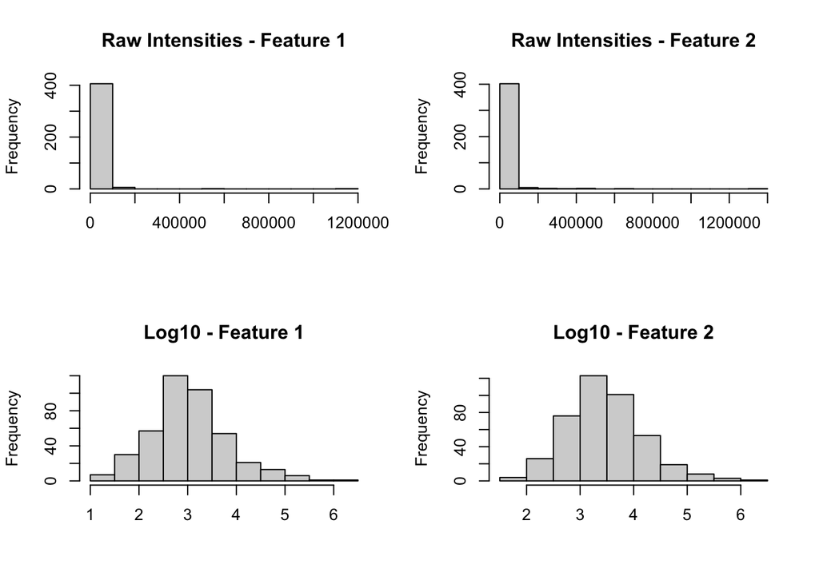

```r
par(mfrow = c(1,1))
```

The raw intensity histograms show strong right-skewness with extreme values. After log10 transformation, the distributions become more symmetric and less heteroscedastic, supporting the use of log-transformed and autoscaled data for PCA and PLS-DA.

# Non linearity

```r
# Convert to standard data frame to avoid tibble recycling issues
X_nozero <- as.data.frame(X)

for(i in 1:nrow(X_nozero)){
  row_vals <- as.numeric(X_nozero[i, ])  # convert row to numeric vector

  # Safeguard: if the row is all zeros
  if(all(row_vals == 0)){
    row_vals[row_vals == 0] <- 1  # placeholder before log10
  } else {
    min_val <- min(row_vals[row_vals > 0], na.rm = TRUE)
    row_vals[row_vals == 0] <- min_val / 2
  }

  X_nozero[i, ] <- row_vals  # assign back properly
}
```

# PCA

A preliminary variance-based feature filtering step (top 20% most variable metabolites) was evaluated as an unsupervised method for noise reduction and dimensionality control. However, this procedure resulted in the removal of several metabolites previously identified as statistically significant in the univariate analysis, consequently reducing the number of biologically relevant features and weakening the discrimination between sexes in downstream multivariate models. Therefore, variance filtering was not retained in the final workflow to preserve subtle yet meaningful metabolic differences.

The matrix was transposed so that samples correspond to rows and metabolites to columns, which is the correct structure required for multivariate analyses such as PCA and PLS-DA, where each row must represent an independent observation:

```r
# Log10 transformation
X_log <- log10(X_nozero)

# Scaling for PCA (samples as rows)
X_scaled <- scale(t(X_log))

# PCA
pca <- prcomp(X_scaled, center = TRUE, scale. = FALSE)
summary(pca)
```

```
## Importance of components:
##                           PC1     PC2     PC3     PC4     PC5     PC6     PC7
## Standard deviation     8.9816 4.96339 4.88671 4.34067 3.71722 3.65416 3.42666
## Proportion of Variance 0.1948 0.05951 0.05768 0.04551 0.03338 0.03225 0.02836
## Cumulative Proportion  0.1948 0.25436 0.31204 0.35755 0.39093 0.42318 0.45154
##                            PC8     PC9    PC10    PC11    PC12    PC13    PC14
## Standard deviation     3.05556 2.93806 2.73820 2.66792 2.60252 2.49513 2.43427
## Proportion of Variance 0.02255 0.02085 0.01811 0.01719 0.01636 0.01504 0.01431
## Cumulative Proportion  0.47410 0.49495 0.51306 0.53025 0.54661 0.56165 0.57596
##                           PC15    PC16    PC17    PC18    PC19    PC20    PC21
## Standard deviation     2.38762 2.33392 2.23402 2.21841 2.16754 2.08917 2.07092
## Proportion of Variance 0.01377 0.01316 0.01206 0.01189 0.01135 0.01054 0.01036
## Cumulative Proportion  0.58973 0.60289 0.61494 0.62683 0.63818 0.64872 0.65908
##                           PC22    PC23    PC24   PC25    PC26    PC27    PC28
## Standard deviation     2.00821 1.96491 1.92119 1.9196 1.89262 1.86169 1.82722
## Proportion of Variance 0.00974 0.00933 0.00892 0.0089 0.00865 0.00837 0.00806
## Cumulative Proportion  0.66882 0.67815 0.68706 0.6960 0.70462 0.71299 0.72105
##                          PC29    PC30    PC31    PC32    PC33    PC34    PC35
## Standard deviation     1.8090 1.78058 1.74800 1.70625 1.68245 1.67253 1.64633
## Proportion of Variance 0.0079 0.00766 0.00738 0.00703 0.00684 0.00676 0.00655
## Cumulative Proportion  0.7290 0.73661 0.74399 0.75103 0.75786 0.76462 0.77117
##                           PC36    PC37    PC38    PC39    PC40    PC41    PC42
## Standard deviation     1.62664 1.60528 1.57799 1.54693 1.52758 1.51314 1.50251
## Proportion of Variance 0.00639 0.00622 0.00601 0.00578 0.00564 0.00553 0.00545
## Cumulative Proportion  0.77756 0.78378 0.78980 0.79558 0.80121 0.80675 0.81220
##                           PC43    PC44    PC45    PC46    PC47    PC48    PC49
## Standard deviation     1.47915 1.46136 1.44511 1.42020 1.40728 1.40112 1.38371
## Proportion of Variance 0.00528 0.00516 0.00504 0.00487 0.00478 0.00474 0.00462
## Cumulative Proportion  0.81748 0.82264 0.82769 0.83256 0.83734 0.84208 0.84671
##                          PC50    PC51    PC52    PC53    PC54    PC55    PC56
## Standard deviation     1.3504 1.34801 1.33024 1.32638 1.30937 1.27730 1.26135
## Proportion of Variance 0.0044 0.00439 0.00427 0.00425 0.00414 0.00394 0.00384
## Cumulative Proportion  0.8511 0.85550 0.85978 0.86403 0.86817 0.87211 0.87595
##                           PC57    PC58    PC59    PC60    PC61    PC62    PC63
## Standard deviation     1.24856 1.23645 1.22854 1.22654 1.20842 1.18012 1.16099
## Proportion of Variance 0.00377 0.00369 0.00365 0.00363 0.00353 0.00336 0.00326
## Cumulative Proportion  0.87972 0.88341 0.88705 0.89069 0.89422 0.89758 0.90084
##                           PC64    PC65    PC66    PC67    PC68    PC69    PC70
## Standard deviation     1.15572 1.14283 1.13768 1.11035 1.10403 1.08755 1.07984
## Proportion of Variance 0.00323 0.00315 0.00313 0.00298 0.00294 0.00286 0.00282
```

[output cut: 18 more lines]

```
## Standard deviation     0.75965 0.7335 0.72827 0.70693 0.7059 0.69253 0.68757
## Proportion of Variance 0.00139 0.0013 0.00128 0.00121 0.0012 0.00116 0.00114
## Cumulative Proportion  0.98069 0.9820 0.98328 0.98448 0.9857 0.98684 0.98799
##                          PC106   PC107   PC108   PC109   PC110   PC111   PC112
## Standard deviation     0.67829 0.66059 0.65036 0.63401 0.61801 0.60428 0.60118
## Proportion of Variance 0.00111 0.00105 0.00102 0.00097 0.00092 0.00088 0.00087
## Cumulative Proportion  0.98910 0.99015 0.99117 0.99214 0.99307 0.99395 0.99482
##                          PC113   PC114   PC115   PC116   PC117   PC118  PC119
## Standard deviation     0.58644 0.58182 0.56989 0.55374 0.54339 0.53442 0.4991
## Proportion of Variance 0.00083 0.00082 0.00078 0.00074 0.00071 0.00069 0.0006
## Cumulative Proportion  0.99565 0.99647 0.99725 0.99800 0.99871 0.99940 1.0000
##                            PC120
## Standard deviation     3.989e-15
## Proportion of Variance 0.000e+00
## Cumulative Proportion  1.000e+00
```

- Summary statistics show very different scales and non-normal distributions
- A few zero values detected → replaced with half of minimum value  
  → required for log10 transformation
- Applied log10(x) to reduce skewness and stabilize variance
- Autoscaling (mean-center + unit variance) to make metabolites comparable

```r
# Sanity check: do sex labels align with PCA samples?
sex_row <- as.character(raw_df[3, ])
sample_names_raw <- sex_row[sex_row %in% c("Male", "Female")]
sample_cols <- colnames(X)

sex <- factor(sample_names_raw[1:length(sample_cols)])

length(sex)
```

```
## [1] 120
```

```r
table(sex)
```

```
## sex
## Female   Male
##     60     60
```

```r
all(!is.na(sex))
```

```
## [1] TRUE
```

```r
identical(length(sex), nrow(pca$x))
```

```
## [1] TRUE
```

```r
pca_scores <- as.data.frame(pca$x[, 1:2])

center <- colMeans(pca_scores)
cov_mat <- cov(pca_scores)

distances <- mahalanobis(pca_scores, center, cov_mat)

# Cutoff (chi with p=0.95 and 2 df)
cutoff <- qchisq(0.95, df = 2)

# plot with condidese matrix
plot(pca$x[,1], pca$x[,2],
     pch = 19,
     col = ifelse(distances > cutoff, "red", "black"), # Outliers red
     xlab = "PC1", ylab = "PC2",
     main = "PCA Outlier Detection (95% CI)")

lines(ellipse(cov_mat, centre = center, level = 0.95), col="blue", lty=2)

text(pca$x[,1], pca$x[,2],
     labels = ifelse(distances > cutoff, rownames(pca$x), ""),
     pos = 3, cex = 0.7)
```

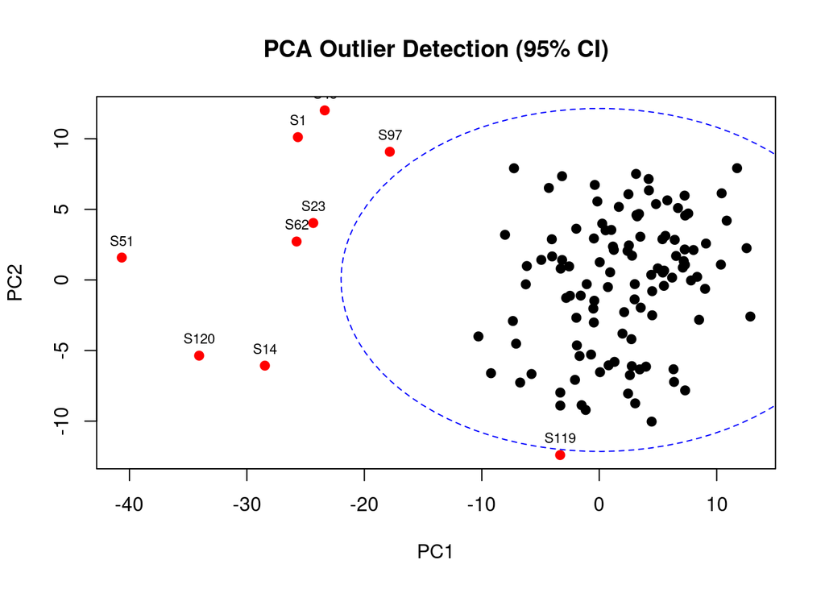

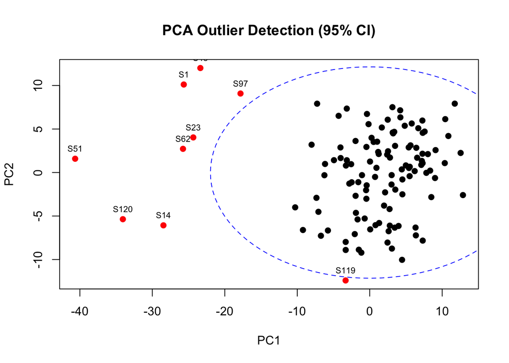

```r
# Identify outliers
outliers <- which(distances > cutoff)
print(paste("Outliers detected:", length(outliers)))
```

```
## [1] "Outliers detected: 9"
```

We detected 9 outliers, but they weren’t removed because outliers reflect real biological variability within the healthy population. Removing them could introduce bias, especially if outliers are unevenly distributed between sexes. Furthermore, the original study did not exclude any samples all 120 subjects were analyzed in full.

We detected 9 outliers, but they weren’t removed because:

Outliers reflect **real biological variability** within the healthy population.  
Removing them could introduce **bias**, especially if outliers are unevenly distributed between sexes.  
Furthermore, the original study **did not exclude any samples** all **120 subjects** were analyzed in full.

# PCA after log transformation

```r
score_df <- data.frame(
  PC1 = pca$x[,1],
  PC2 = pca$x[,2],
  Sex = sex
)

ggplot(score_df, aes(PC1, PC2, color = Sex)) +
  geom_point(size = 3) +
  theme_classic() +
  ggtitle("PCA After Log10 Transform + Scaling")
```

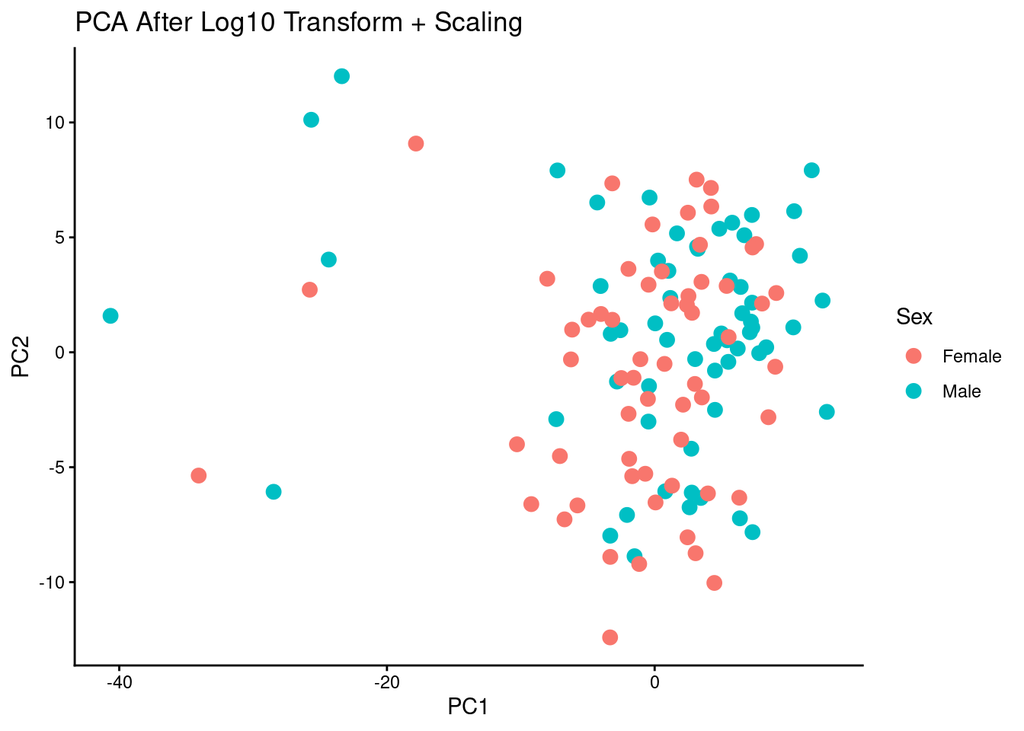

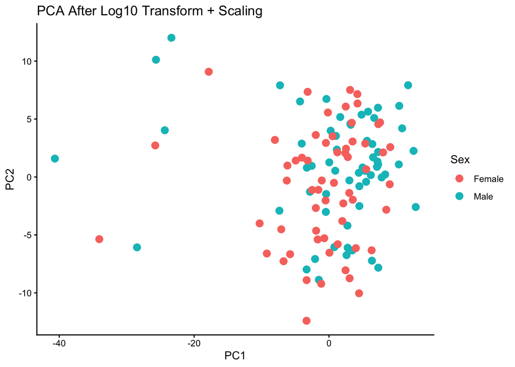

```r
# Scree plot (PCA Variance Explained)
variance <- pca$sdev^2 / sum(pca$sdev^2)

plot(variance[1:10], type="b", pch=19,
     xlab="PC", ylab="Proportion of Variance",
     main="Scree Plot - PCA")
```

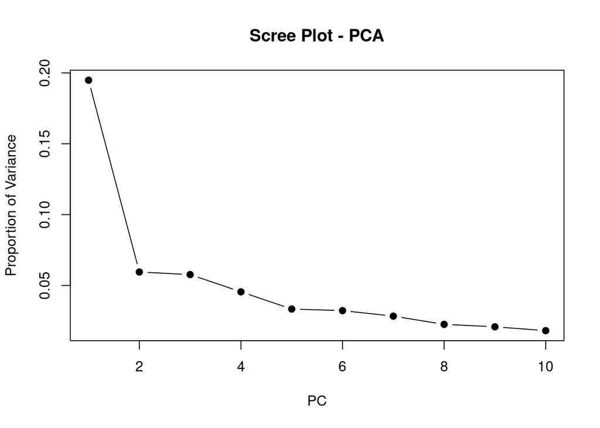

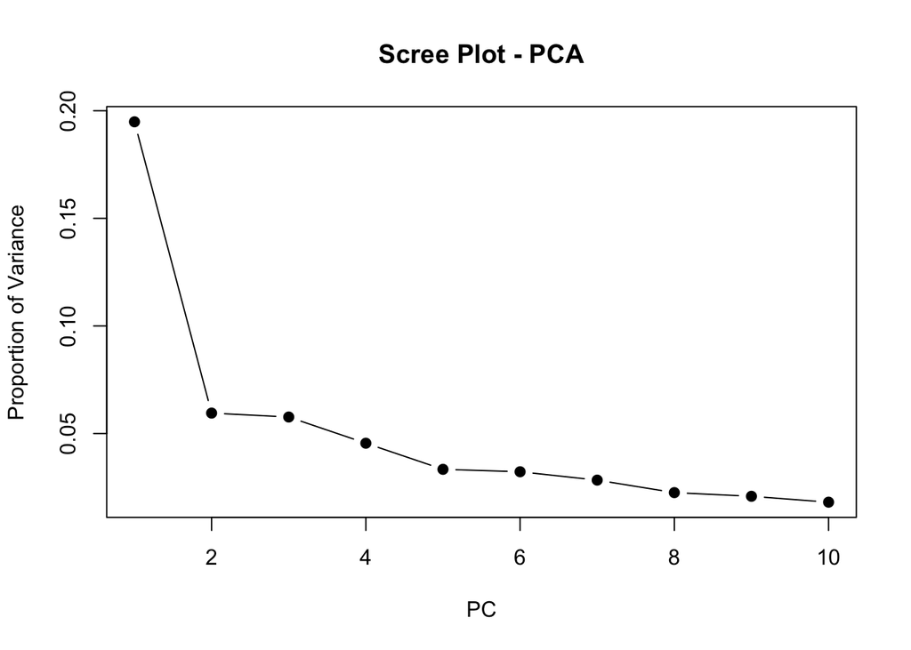

# Split Test/Training

We split the data into training and test sets (70/30) and perform univariate t-tests on the training set only. FDR correction is applied to identify metabolites significantly different between sexes.

```r
set.seed(123)

# split the data into training and test sets(70/30)
train_index <- createDataPartition(sex, p = 0.7, list = FALSE)

X_train <- X_scaled[train_index, ]
X_test  <- X_scaled[-train_index, ]

X_train <- as.data.frame(X_train)
X_test  <- as.data.frame(X_test)

y_train <- sex[train_index]
y_test  <- sex[-train_index]

pvals <- apply(X_train, 2, function(x) t.test(x ~ y_train)$p.value)
pvals_fdr <- p.adjust(pvals, method = "fdr")

head(sort(pvals_fdr))
```

```
##         V22        V399         V10         V84         V51        V113
## 0.001753165 0.002134547 0.044318477 0.044318477 0.044551591 0.044551591
```

Several metabolites show significant sex differences (FDR < 0.05). These will be considered as candidates for biomarker selection in the supervised modeling step.

# Initials PLS-DA

An initial PLS-DA model with 10 components was trained on the training set to evaluate whether the metabolomic profiles discriminate between sexes.

```r
#Initial PLS-DA model

pls_initial <- mixOmics::plsda(X_train, y_train, ncomp = 10)

mixOmics::plotIndiv(pls_initial, comp = c(1,2),
          group = y_train, legend = TRUE,
          title = "Initial PLS-DA (Training Set)")
```

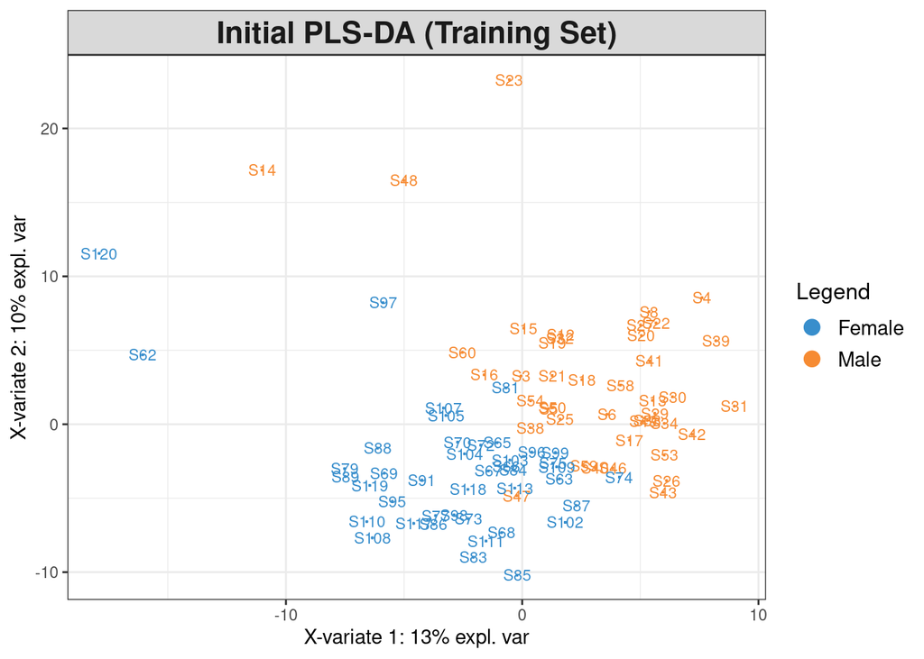

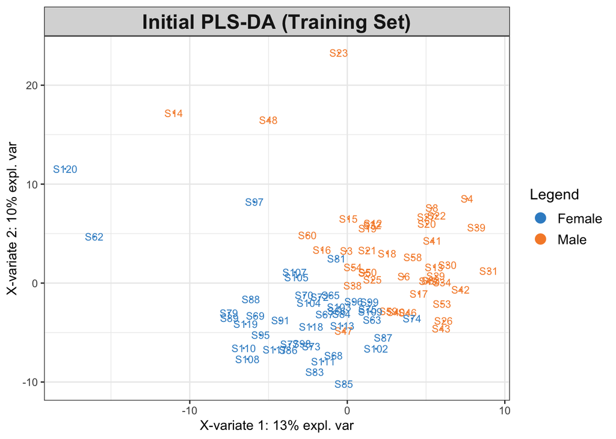

# Internal Validation: 5-Fold CV + AUCROC

A 5-fold cross-validation was used on the training set to determine the optimal number of latent variables (LVs) for the PLS-DA model, using AUC as the performance metric.

```r
set.seed(123)

folds <- createFolds(y_train, k = 5, returnTrain = TRUE)
auc_results <- data.frame(LV = integer(), AUC = numeric())

for (lv in 1:5) {
  auc_fold <- c()

  for (f in folds) {
    model <- mixOmics::plsda(X_train[f,], y_train[f], ncomp = lv)
    pred <- predict(model, X_train[-f,])$predict[,1,lv]
    roc_obj <- roc(y_train[-f], pred)
    auc_fold <- c(auc_fold, auc(roc_obj))
  }

  auc_results <- rbind(auc_results,
                       data.frame(LV = lv,
                                  AUC = mean(auc_fold)))
}
auc_results
```

```
##   LV       AUC
## 1  1 0.7246914
## 2  2 0.7500772
## 3  3 0.8280478
## 4  4 0.8102623
## 5  5 0.8032793
```

LV = 3 showed the highest mean AUC, and was therefore selected as the optimal number of components for the final PLS-DA model.

# Univariate Analysis on Training set (Male vs Female)

Univariate Welch t-tests were applied to each metabolite in the training set, followed by FDR correction. Mean differences (Male – Female) were calculated to determine the direction of change.

```r
# Compute raw p-values using Welch t-test for each metabolite
pvals <- apply(X_train, 2, function(x) t.test(x ~ y_train)$p.value)

# FDR correction (Benjamini-Hochberg)
pvals_fdr <- p.adjust(pvals, method = "fdr")


fc <- apply(X_train, 2, function(x) mean(x[y_train == "Male"]) -
                               mean(x[y_train == "Female"]))


uni_results <- data.frame(
  Metabolite = colnames(X_train),
  p_value = pvals,
  p_FDR = pvals_fdr,
  mean_diff = fc
)


uni_results <- uni_results[order(uni_results$p_FDR), ]
significant <- uni_results[uni_results$p_FDR < 0.05, ]
significant
```

```
##      Metabolite      p_value       p_FDR  mean_diff
## V22         V22 4.234697e-06 0.001753165 -0.9561637
## V399       V399 1.031182e-05 0.002134547 -0.9196217
## V10         V10 4.281978e-04 0.044318477  0.7449845
## V84         V84 3.253387e-04 0.044318477 -0.7615165
## V51         V51 6.958870e-04 0.044551591 -0.7565657
## V113       V113 6.825835e-04 0.044551591  0.7638415
## V291       V291 7.532878e-04 0.044551591 -0.6712124
## V57         V57 8.641712e-04 0.044720859 -0.6346747
## V250       V250 1.080601e-03 0.049707666  0.6825126
```

Several metabolites showed significant sex differences (FDR < 0.05). These features represent potential biomarkers and will be further evaluated in the supervised model.

# Volcano Plot - Univariate Analysis

A volcano plot was generated to visualize effect size (mean difference) against statistical significance (FDR-corrected p-values).

```r
volcano <- uni_results
volcano$logP <- -log10(volcano$p_FDR)

ggplot(volcano, aes(x = mean_diff, y = logP)) +
  geom_point(alpha = 0.7) +
  geom_hline(yintercept = -log10(0.05), col = "red", lty = 2) +
  theme_classic() +
  xlab("Mean Difference (Male – Female)") +
  ylab("-log10(FDR)") +
  ggtitle("Volcano Plot — Univariate Analysis (Training Set)")
```

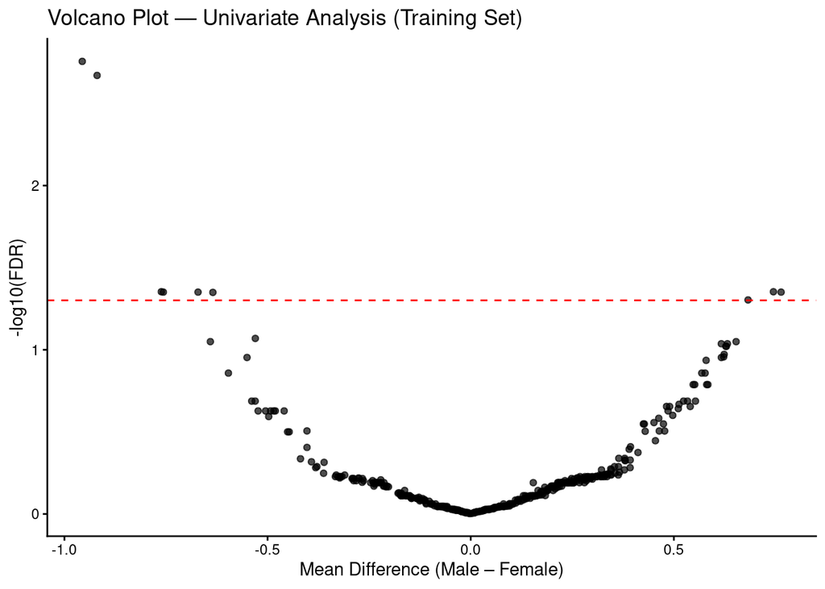

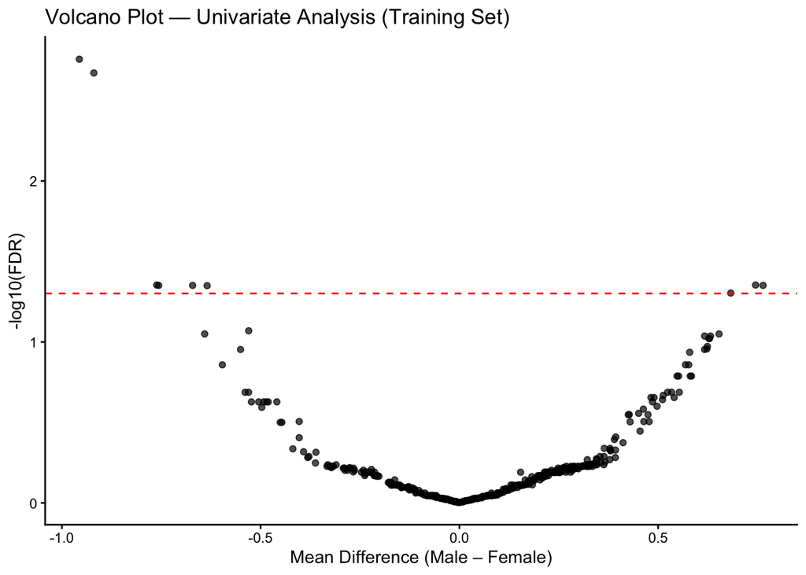

```r
colnames(X_train) <- paste0("X", 1:ncol(X_train))
colnames(X_test)  <- paste0("X", 1:ncol(X_test))

y_train <- as.factor(y_train)
y_test  <- as.factor(y_test)
```

```r
set.seed(30)

perf_res <- perf(pls_initial,
                 validation = "Mfold",
                 folds = 5,
                 nrepeat = 5,
                 progressBar = FALSE)

plot(perf_res, sd = TRUE)
```

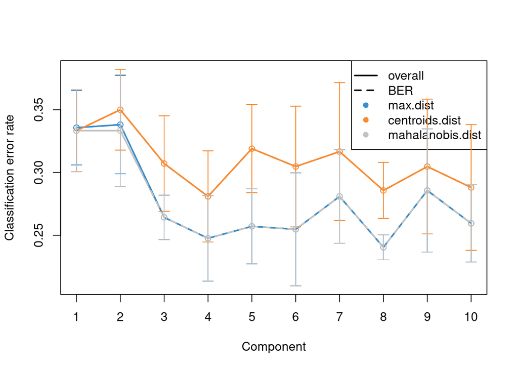

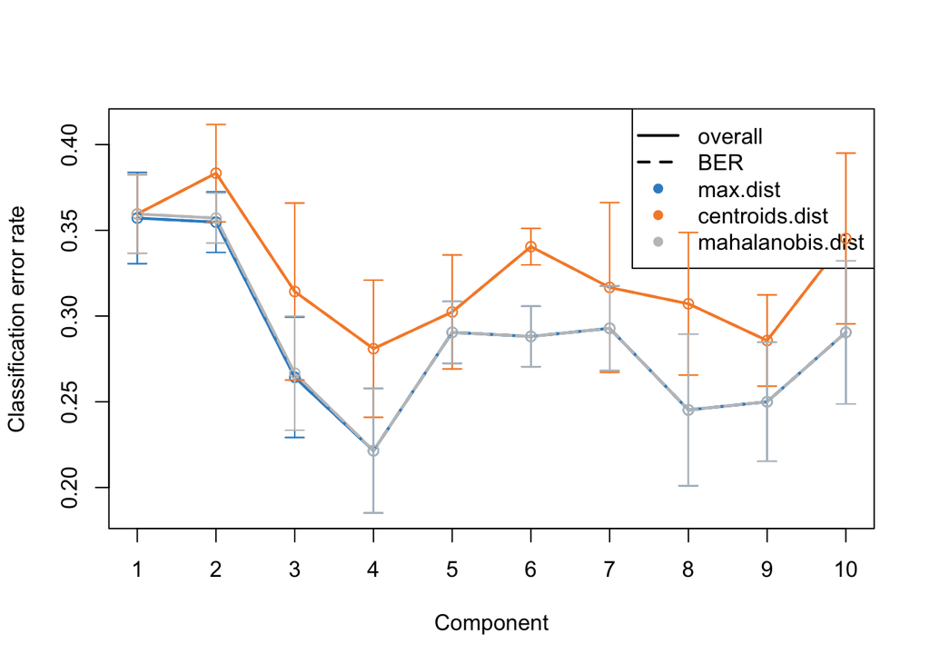

Calculate the optimal number of components, using other metrics, like BER. This shows that increasing the number of components doesn’t always decrease the error.

As an additional exploratory validation, the perf() method from mixOmics was applied. Although BER suggested 4 components, this criterion is less appropriate for binary classification than AUC. Therefore, AUC-based tuning remained the primary selection method.

```r
optimal_ncomp <- which.min(perf_res$error.rate$BER)
optimal_ncomp
```

[output not shown]

```
## [1] 4
```

```r
optimal_ncomp <-3
pls_final <- mixOmics::plsda(X_train, y_train, ncomp = optimal_ncomp)

mixOmics::plotIndiv(pls_final, comp = c(1,2),
          group = y_train, legend = TRUE,
          title = "Final PLS-DA (Training Set) — 3 components")
```

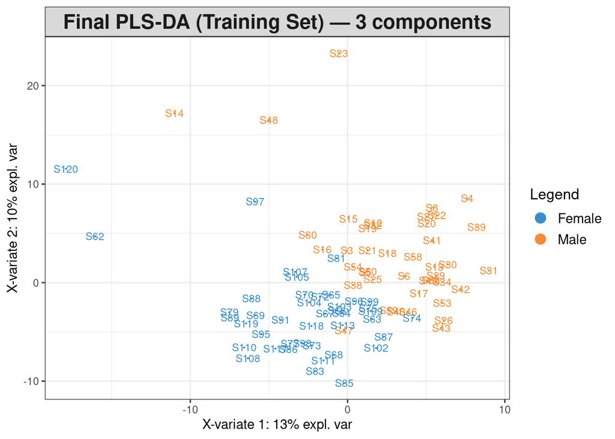

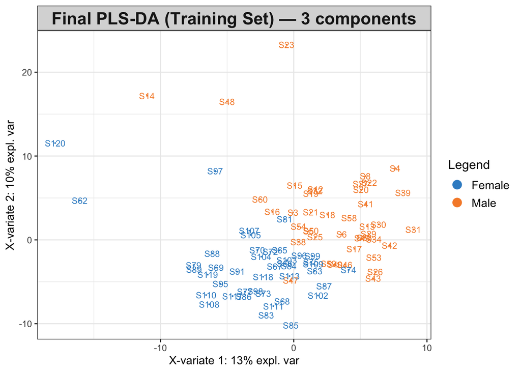

We selected n = 3 components because they maximised the AUC during cross-validation while avoiding unnecessary model complexity. Although BER suggested 4 components, the improvement was marginal and adding extra components risks overfitting, especially in a two-class dataset.

```r
pred_test <- predict(pls_final, X_test)
pred_class <- pred_test$class$max.dist[, optimal_ncomp]

table(True = y_test, Predicted = pred_class)
```

```
##         Predicted
## True     Female Male
##   Female     14    4
##   Male        5   13
```

```r
mean(pred_class == y_test)
```

```
## [1] 0.75
```

```r
test_variates <- pred_test$variates

test_df <- data.frame(
  Comp1 = test_variates[,1],
  Comp2 = if (optimal_ncomp >= 2) test_variates[,2] else rep(0, nrow(test_variates)),
  Class = y_test
)

ggplot(test_df, aes(Comp1, Comp2, color = Class)) +
  geom_point(size = 3) +
  theme_minimal() +
  ggtitle("PLS-DA Test Set Scores")
```

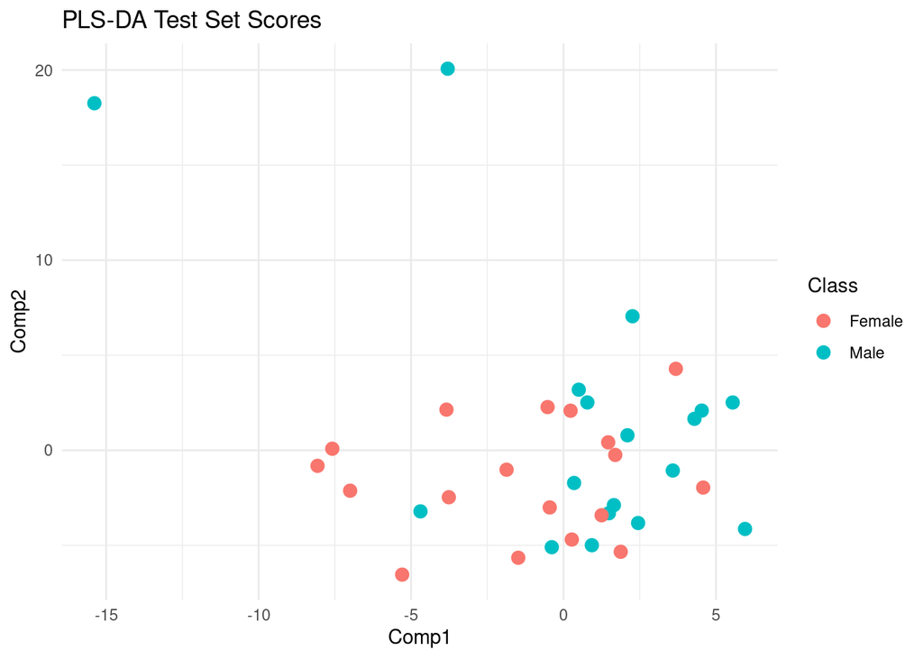

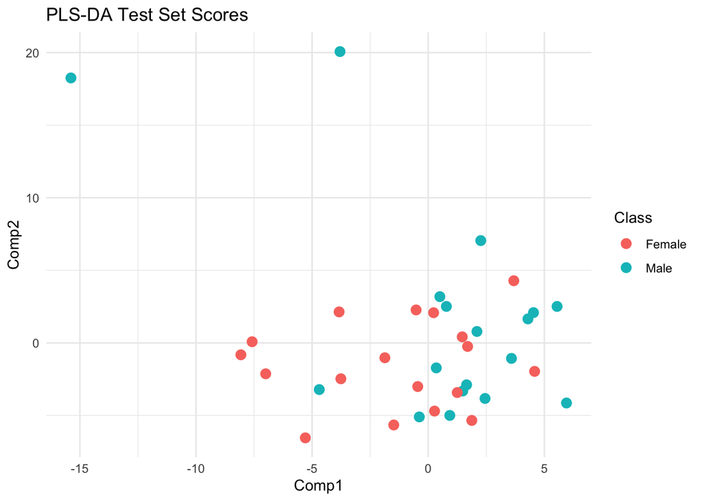

The final PLS-DA model does not show a visibly stronger separation because the main class structure was already captured by the first two components in the initial model. Tuning improves model stability and classification performance, but these gains occur mostly beyond component 2, which is why the 2D score plot appears similar.

# Feature Selection:

## Calculate and Rank VIP Scores

The VIP score for each metabolite measures its relevance to the model components and the classification of the samples.

```r
# 1. Extract the VIP scores matrix from the final PLS-DA model
# We focus on the scores from the first component (LV1)
vip_matrix <- vip(pls_final)
vip_scores_lv1 <- vip_matrix[, 1]

# 2. Order the metabolites from most important to least important
vip_ranked <- sort(vip_scores_lv1, decreasing = TRUE)

# 3. Convert to a data frame for plotting and analysis
vip_df <- data.frame(
  Metabolite = names(vip_ranked),
  VIP = vip_ranked
)

# 4. Visualize the top 20 most important metabolites
top_n <- 20
vip_top <- head(vip_df, top_n)

# plot
ggplot(vip_top, aes(x = reorder(Metabolite, VIP), y = VIP)) +
  geom_bar(stat = "identity", fill = "light blue") +
  geom_hline(yintercept = 1, linetype = "dashed", color = "red", size = 0.8) +
  coord_flip() +
  theme_minimal(base_size = 14) +
  labs(title = paste("Top", top_n, "Metabolites by VIP Score (LV1)"),
       y = "VIP Score",
       x = "Metabolite")
```

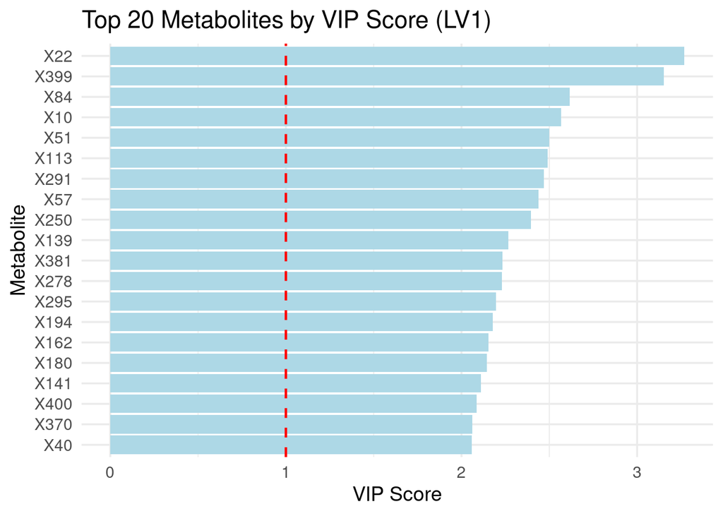

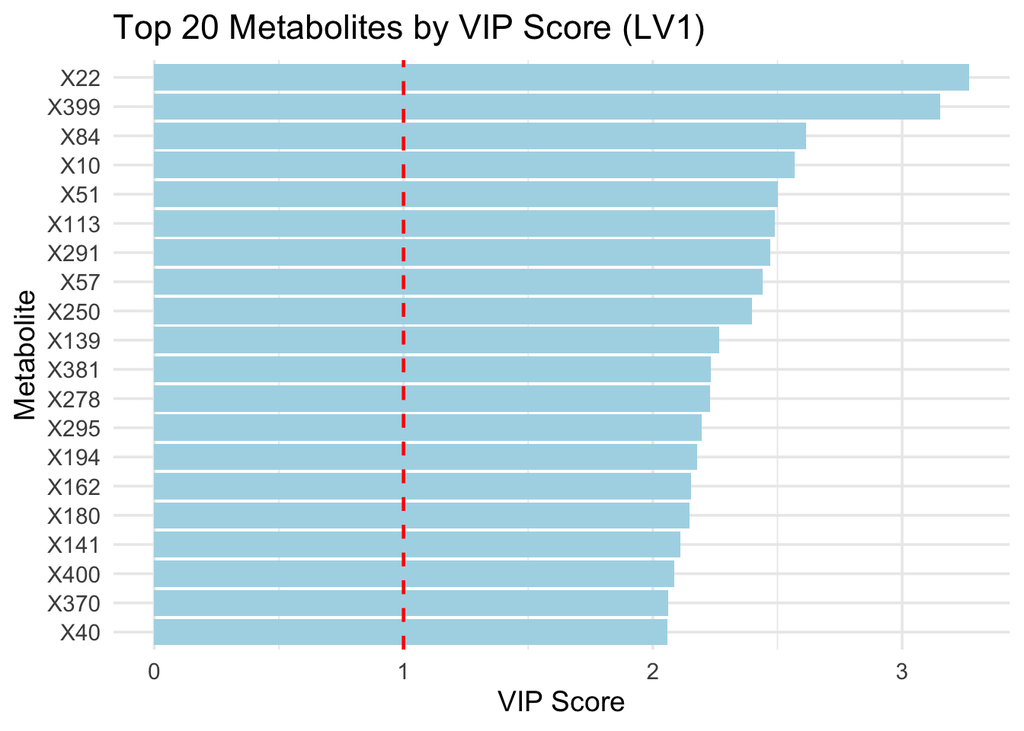

# Implement Recursive Feature Elimination (RFE) using the k-NN Classifier

We then implemented Recursive Feature Elimination (RFE), a supervised approach, using the k-Nearest Neighbors (k-NN) classifier to determine the optimal, minimal set of metabolites that maximizes classification accuracy.

```r
set.seed(123)

# Define subset sizes for RFE
subset_sizes <- c(2, 5, 10, 15, 20, 25, 30, 40, 50)

# RFE control with default caret functions
rfe_control <- rfeControl(
  functions = caretFuncs,   # default ranking
  method = "repeatedcv",
  number = 5,
  repeats = 5,
  verbose = FALSE,          # suppress intermediate output
  returnResamp = "all"
)

# Execute RFE
rfe_results <- rfe(
  x = X_train,
  y = y_train,
  sizes = subset_sizes,
  rfeControl = rfe_control,
  method = "knn",
  tuneLength = 5,
  metric = "Accuracy",
  preProcess = c("center","scale")
)

# Extract optimal features
optimal.nfeatures.rfe <- rfe_results$bestSubset
optimal_features_rfe <- rfe_results$optVariables

cat("Optimal number of features:", optimal.nfeatures.rfe, "\n")
```

```
## Optimal number of features: 20
```

```r
cat("Top selected features:", head(optimal_features_rfe, 10), "\n")
```

```
## Top selected features: X22 X399 X51 X250 X84 X57 X113 X291 X10 X180
```

# Plot the results of the RFE function and print the table

```r
# Extract resampling results from RFE
rfe_df <- rfe_results$results

# Plot accuracy vs. number of variables
ggplot(rfe_df, aes(x = Variables, y = Accuracy)) +
  geom_line(color = "steelblue", size = 1.2) +
  geom_point(size = 3, color = "steelblue") +
  geom_point(data = subset(rfe_df, Variables == rfe_results$bestSubset),
             aes(x = Variables, y = Accuracy),
             color = "red", size = 4, shape = 21, fill = "red") +
  theme_minimal(base_size = 14) +
  labs(title = "RFE Accuracy vs. Number of Features",
       x = "Number of Features",
       y = "Accuracy (Repeated CV)")
```

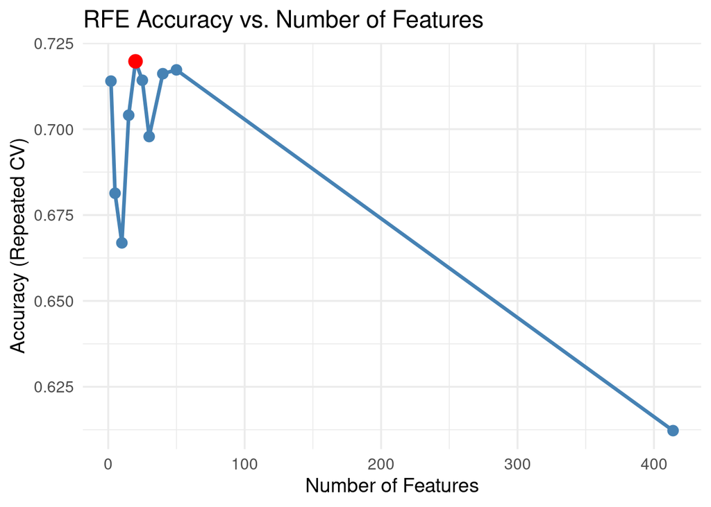

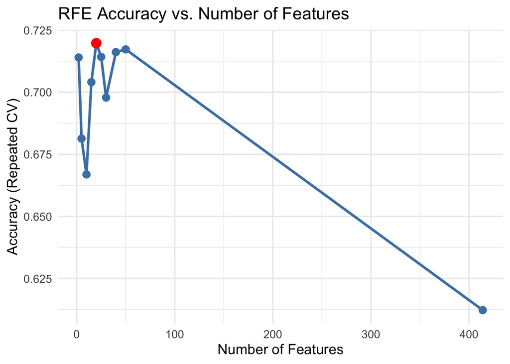

```r
# Print the table with the results to validate the plot representation
kable(round(rfe_df, 3), caption = "RFE Accuracy by Number of Features")
```

RFE Accuracy by Number of Features

| Variables | Accuracy | Kappa | AccuracySD | KappaSD |
| --- | --- | --- | --- | --- |
| 2 | 0.714 | 0.425 | 0.134 | 0.270 |
| 5 | 0.681 | 0.362 | 0.090 | 0.179 |
| 10 | 0.667 | 0.331 | 0.095 | 0.194 |
| 15 | 0.704 | 0.408 | 0.097 | 0.192 |
| 20 | 0.720 | 0.439 | 0.098 | 0.195 |
| 25 | 0.714 | 0.428 | 0.083 | 0.165 |
| 30 | 0.698 | 0.395 | 0.096 | 0.194 |
| 40 | 0.716 | 0.432 | 0.095 | 0.190 |
| 50 | 0.717 | 0.436 | 0.114 | 0.228 |
| 414 | 0.612 | 0.225 | 0.103 | 0.206 |

The process identified the optimal number of features to be 20. The model achieved a maximum cross-validated accuracy of 0.720 using this subset.

# Final Model Training and Evaluation with Optimal Features

The final PLS-DA model was trained using the 20 metabolites selected by the RFE procedure and the previously optimized number of latent variables (n = 3). Restricting the model to this reduced feature set was intended to limit model complexity while retaining metabolites that contributed most to class discrimination during training.

```r
# 1. Define the number of components (LVs)
# Use the previously optimized ncomp = 3.
optimal_ncomp <- 3

# 2. Subset the training and test data to only the optimal features
X_train_optimal <- X_train[, optimal_features_rfe]
X_test_optimal  <- X_test[, optimal_features_rfe]

# 3. Train the final PLS-DA model using ONLY the optimal features
pls_final_optimal <- mixOmics::plsda(X_train_optimal, y_train, ncomp = optimal_ncomp)

cat("Final PLS-DA model trained with:", optimal.nfeatures.rfe, "metabolites.\n")
```

```
## Final PLS-DA model trained with: 20 metabolites.
```

```r
# 4. Predict on the Test Set
pred_test_optimal <- predict(pls_final_optimal, X_test_optimal)

# Extract predicted class using max distance for the chosen ncomp
pred_class_optimal <- pred_test_optimal$class$max.dist[, optimal_ncomp]

# 5. Evaluate Performance
cat("\nPerformance on Test Set\n")
```

```
##
## Performance on Test Set
```

```r
# Confusion Matrix
confusion_matrix_optimal <- table(True = y_test, Predicted = pred_class_optimal)
print(confusion_matrix_optimal)
```

```
##         Predicted
## True     Female Male
##   Female     16    2
##   Male        5   13
```

```r
# Overall Accuracy
accuracy_optimal <- mean(pred_class_optimal == y_test)
cat("\nOverall Accuracy:", round(accuracy_optimal, 4), "\n")
```

```
##
## Overall Accuracy: 0.8056
```

```r
# Custom BER function (can't be exported directly)
BER <- function(conf_matrix) {
  # Convert to matrix
  cm <- as.matrix(conf_matrix)

  # Assume binary classification: rows = true, cols = predicted
  # Sensitivity for class 1
  sens1 <- cm[1,1] / sum(cm[1,])
  # Sensitivity for class 2
  sens2 <- cm[2,2] / sum(cm[2,])

  # BER = 1 - mean(sensitivities)
  ber <- 1 - mean(c(sens1, sens2))
  return(ber)
}

ber_optimal <- BER(confusion_matrix_optimal)
cat("Balanced Error Rate (BER):", round(ber_optimal, 4), "\n")
```

```
## Balanced Error Rate (BER): 0.1944
```

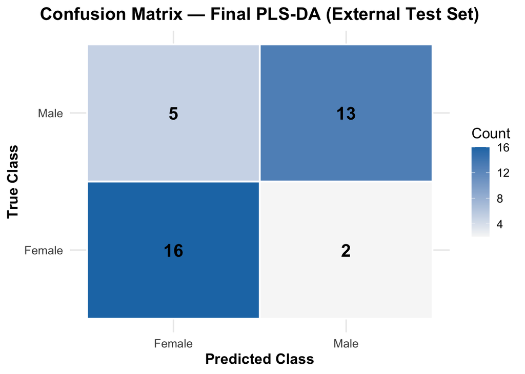

```r
conf_df_optimal <- as.data.frame(confusion_matrix_optimal)
colnames(conf_df_optimal) <- c("True", "Predicted", "Count")


ggplot(conf_df_optimal, aes(x = Predicted, y = True, fill = Count)) +
  geom_tile(color = "white", linewidth = 0.8) +
  geom_text(aes(label = Count), size = 6, fontface = "bold") +
  scale_fill_gradient(low = "#f7f7f7", high = "#1f78b4") +
  labs(
    title = "Confusion Matrix — Final PLS-DA (External Test Set)",
    x = "Predicted Class",
    y = "True Class",
    fill = "Count"
  ) +
  theme_minimal(base_size = 14) +
  theme(
    plot.title = element_text(face = "bold", hjust = 0.5),
    axis.title = element_text(face = "bold"),
    legend.position = "right"
  )
```

# Visualization of Test Set Scores

```r
# Visualization of Test Set Scores
# Extract the sample scores (variates) for the optimal model
test_variates_optimal <- pred_test_optimal$variates

# Create a data frame for plotting
test_df_optimal <- data.frame(
  Comp1 = test_variates_optimal[,1],
  Comp2 = if (optimal_ncomp >= 2) test_variates_optimal[,2] else rep(0, nrow(test_variates_optimal)),
  Class = y_test
)

# Generate the Score Plot
ggplot(test_df_optimal, aes(Comp1, Comp2, color = Class)) +
  geom_point(size = 3) +
  theme_minimal(base_size = 14) +
  scale_color_manual(values = c("Female" = "red", "Male" = "blue")) +
  ggtitle(paste("Final PLS-DA Test Set Scores (Features:", optimal.nfeatures.rfe, ")")) +
  labs(x = "Component 1", y = "Component 2")
```

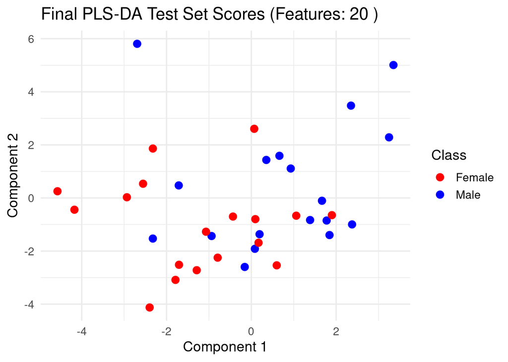

The score plot displays the projection of test set samples onto the first two latent variables of the optimized PLS-DA model.

# External validation of the results

External validation was carried out using the held-out test set and the final PLS-DA model trained on the selected metabolite subset.

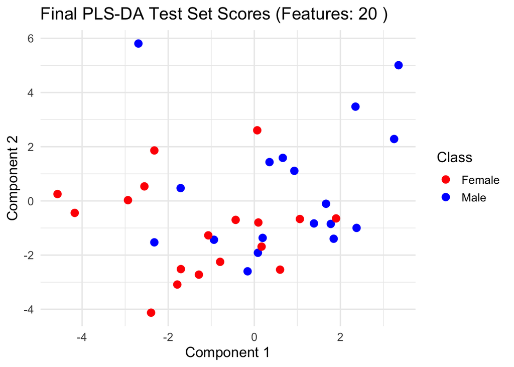